# Pedometer Analysis : Assessment 1

Abhishek Singh

```r
library(lattice)
library(mice)
```

## Loading and preprocessing the data

```r
zipName<-"Motion.zip"
UnzipFile<-"activity.csv"
DURL<-"https://d396qusza40orc.cloudfront.net/repdata%2Fdata%2Factivity.zip"

#Downloading and unzipping (if not done already)
if(!file.exists(zipName))
  download.file(DURL,zipName)
if(!file.exists(UnzipFile))
  unzip(zipName)

steps<-read.csv(UnzipFile)
steps$date<-as.Date(steps$date,"%Y-%m-%d")
```

## What is mean total number of steps taken per day?

##### 1. Calculate the total number of steps taken per day

```r
totSteps<-tapply(steps$steps,steps$date,sum,na.rm=TRUE)
```

##### 2. Calculate and report the mean and median of total number of steps taken per day

```r
MeanStepsPerDay<-mean(totSteps)
MedianStepsPerDay<-median(totSteps)
```

- Mean= 9354.2295082
- Median= 10395

##### 3. Make a histogram of the total number of steps taken each day

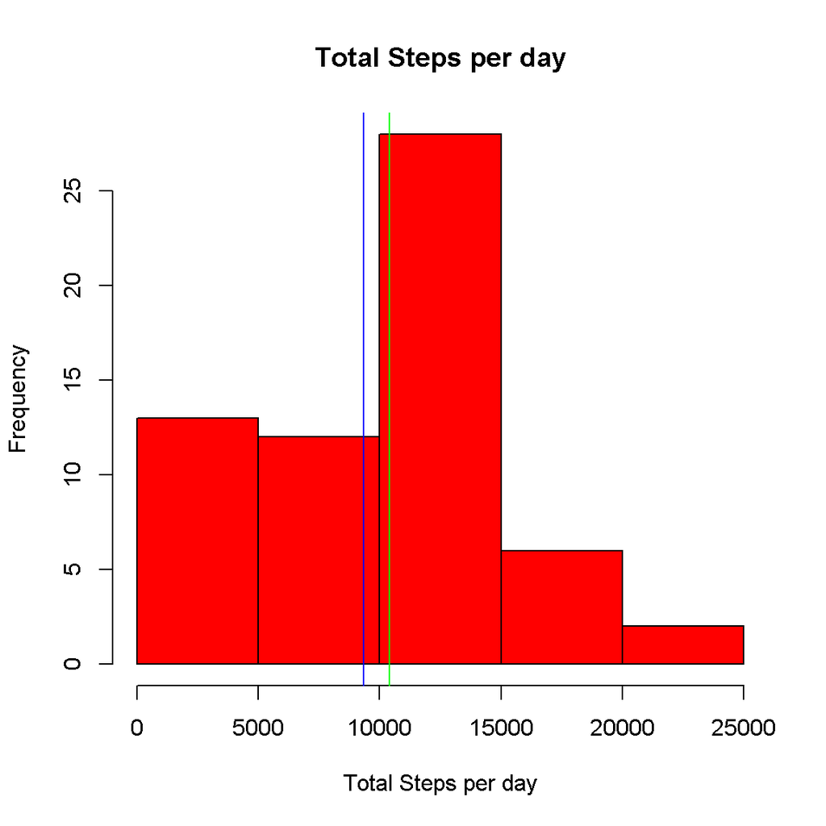

```r
hist(totSteps,xlab="Total Steps per day",col="red",main="Total Steps per day")
abline(v=MeanStepsPerDay,col="blue")
abline(v=MedianStepsPerDay,col="green")
```

## What is the average daily activity pattern?

##### 1. Make a time series plot (i.e. type = “l”) of the 5-minute interval (x-axis) and the average number of steps taken, averaged across all days (y-axis)

```r
totStepsInInterval<-tapply(steps$steps,steps$interval,mean,na.rm=TRUE)
```

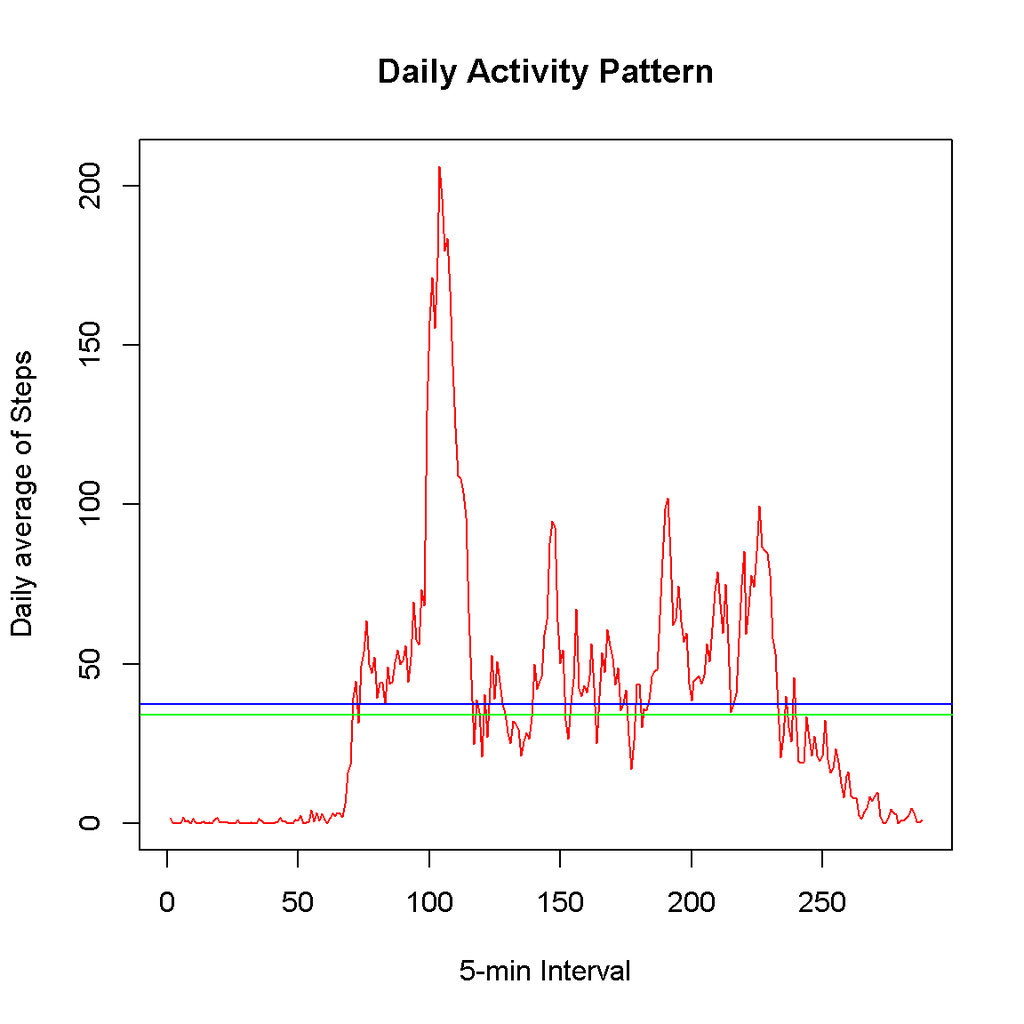

```r
plot(totStepsInInterval,type="l",col="red",xlab="5-min Interval",
      ylab="Daily average of Steps",main="Daily Activity Pattern")
abline(h=mean(totStepsInInterval),col="blue")
abline(h=median(totStepsInInterval),col="green")
```

##### 2. Which 5-minute interval, on average across all the days in the dataset, contains the maximum number of steps?

```r
maxInt<-names(which.max(totStepsInInterval))
```

- Max value interval=835